# Exploratory Data Analysis.¶

## Introduction

H&M Group was founded on October 4, 1947 by Erling Persson in Sweden. Initially, it offered clothes intended for women. Erling Persson started selling the clothes he prepared in a shop called "Hennes". The letter H in H&M's logo is derived from the name Hennes.Later, this business continued to develop, and Erling Persson bought a store called Mauritz Widfoss in Stockholm, so Mauritz was added to Hennes. Currently, H&M is a brand with 53 online and 4,850 stores. Their online store offers a very wide range of products, so the data is worth studying.

Content:

1. Importing Libraries.
2. Load the Data.
3. Articles Variables Description
4. Customers Variable Description
5. Transactions Variable Description

### 1.First Steps: Importing libraries.

```python
import numpy as np
import pandas as pd
import seaborn as sns
from matplotlib import pyplot as plt
from tqdm.notebook import tqdm
```

### 2. Load : Load the data.

```python
articles = pd.read_csv("articles.csv")
customers = pd.read_csv("customers.csv")
transactions = pd.read_csv("transactions_train.csv")
```

### 3.Articles Variable Description

Unique identifier of an articles.

1. article_id : (int 64) An unique 9-digit identifier of the article.

5 columns related to products:

1. product_code : 6 digit product code.
2. prod_name : (object) The name of a product.(not the same.) 45 875 unique values.
3. product_type_no: (int64) Product type number, 131 unique values.
4. product_type_name: (object) Name of a product type, equivalent of product_type_no.
5. product_group_name:Name of product groups. Total 19.

2 columns related to the pattern:

1. graphical_appearance_no: (int64) - code of a pattern. 30 unique values.
2. graphical_appearance_name : (object) - name of a pattern. 30 unique values.

6 columns related to the color:

1. colour_group_code: (int64) The group of color
2. colour_group_name (object) The group of color name.
3. perceived_colour_value_id: Perceived color id. 8 unique values.
4. perceived_colour_value_name:perceived color name. 8 unique values.
5. perceived_colour_master_id: perceived master color id. 20 unique values.
6. perceived_colour_master_name:perceived master color name. 20 unique values.

2 columns related to the department:

1. department_no: A unique identifier of every dep
2. department_name: A unique identifier of a name.

4 columns related to the index:

1. index_name:A unique identifier for each name.
2. index_code: index name, 10 unique values.
3. index_group_no: index_group_name: : A group of indeces and its name.
4. index_group_name:A group of indeces and its name.

2 columns related to the section:

1. section_no: A unique identifier of every section
2. section_name: : A unique identifier of every section name.

2 columns related to the garment group:

1. garment_group_no:A unique identifier of every garment
2. garment_group_name:A unique identifier of every garment name.

1 column with a detailed description of the article:

1. detail_desc: : Descriptions about the product.

### 3.1 Articles : View articles data.

```python
articles.head()
```

|  | article_id | product_code | prod_name | product_type_no | product_type_name | product_group_name | graphical_appearance_no | graphical_appearance_name | colour_group_code | colour_group_name | ... | department_name | index_code | index_name | index_group_no | index_group_name | section_no | section_name | garment_group_no | garment_group_name | detail_desc |
| --- | --- | --- | --- | --- | --- | --- | --- | --- | --- | --- | --- | --- | --- | --- | --- | --- | --- | --- | --- | --- | --- |
| 0 | 108775015 | 108775 | Strap top | 253 | Vest top | Garment Upper body | 1010016 | Solid | 9 | Black | ... | Jersey Basic | A | Ladieswear | 1 | Ladieswear | 16 | Womens Everyday Basics | 1002 | Jersey Basic | Jersey top with narrow shoulder straps. |
| 1 | 108775044 | 108775 | Strap top | 253 | Vest top | Garment Upper body | 1010016 | Solid | 10 | White | ... | Jersey Basic | A | Ladieswear | 1 | Ladieswear | 16 | Womens Everyday Basics | 1002 | Jersey Basic | Jersey top with narrow shoulder straps. |
| 2 | 108775051 | 108775 | Strap top (1) | 253 | Vest top | Garment Upper body | 1010017 | Stripe | 11 | Off White | ... | Jersey Basic | A | Ladieswear | 1 | Ladieswear | 16 | Womens Everyday Basics | 1002 | Jersey Basic | Jersey top with narrow shoulder straps. |
| 3 | 110065001 | 110065 | OP T-shirt (Idro) | 306 | Bra | Underwear | 1010016 | Solid | 9 | Black | ... | Clean Lingerie | B | Lingeries/Tights | 1 | Ladieswear | 61 | Womens Lingerie | 1017 | Under-, Nightwear | Microfibre T-shirt bra with underwired, moulde... |
| 4 | 110065002 | 110065 | OP T-shirt (Idro) | 306 | Bra | Underwear | 1010016 | Solid | 10 | White | ... | Clean Lingerie | B | Lingeries/Tights | 1 | Ladieswear | 61 | Womens Lingerie | 1017 | Under-, Nightwear | Microfibre T-shirt bra with underwired, moulde... |

5 rows × 25 columns

### 3.1.2. The columns of the Articles dataframe.

```python
articles.columns
```

```
Index(['article_id', 'product_code', 'prod_name', 'product_type_no',
       'product_type_name', 'product_group_name', 'graphical_appearance_no',
       'graphical_appearance_name', 'colour_group_code', 'colour_group_name',
       'perceived_colour_value_id', 'perceived_colour_value_name',
       'perceived_colour_master_id', 'perceived_colour_master_name',
       'department_no', 'department_name', 'index_code', 'index_name',
       'index_group_no', 'index_group_name', 'section_no', 'section_name',
       'garment_group_no', 'garment_group_name', 'detail_desc'],
      dtype='object')
```

### 3.1.3. Information about the Articles dataframe.

```python
articles.info()
```

```
<class 'pandas.core.frame.DataFrame'>
RangeIndex: 105542 entries, 0 to 105541
Data columns (total 25 columns):
 #   Column                        Non-Null Count   Dtype
---  ------                        --------------   -----
 0   article_id                    105542 non-null  int64
 1   product_code                  105542 non-null  int64
 2   prod_name                     105542 non-null  object
 3   product_type_no               105542 non-null  int64
 4   product_type_name             105542 non-null  object
 5   product_group_name            105542 non-null  object
 6   graphical_appearance_no       105542 non-null  int64
 7   graphical_appearance_name     105542 non-null  object
 8   colour_group_code             105542 non-null  int64
 9   colour_group_name             105542 non-null  object
```

[output cut: 17 more lines]

### 3.1.4.Let's see the product names.

```python
print(articles['product_type_name'].value_counts(dropna=False))
```

```
Trousers         11169
Dress            10362
Sweater           9302
T-shirt           7904
Top               4155
                 ...
Keychain             1
Headband             1
Cushion              1
Blanket              1
Clothing mist        1
Name: product_type_name, Length: 131, dtype: int64
```

### 3.1.5. Calculation and display of custom statistics.

```python
articles.describe()
```

|  | article_id | product_code | product_type_no | graphical_appearance_no | colour_group_code | perceived_colour_value_id | perceived_colour_master_id | department_no | index_group_no | section_no | garment_group_no |
| --- | --- | --- | --- | --- | --- | --- | --- | --- | --- | --- | --- |
| count | 1.055420e+05 | 105542.000000 | 105542.000000 | 1.055420e+05 | 105542.000000 | 105542.000000 | 105542.000000 | 105542.000000 | 105542.000000 | 105542.000000 | 105542.000000 |
| mean | 6.984246e+08 | 698424.563378 | 234.861875 | 1.009515e+06 | 32.233822 | 3.206183 | 7.807972 | 4532.777833 | 3.171534 | 42.664219 | 1010.438290 |
| std | 1.284624e+08 | 128462.384432 | 75.049308 | 2.241359e+04 | 28.086154 | 1.563839 | 5.376727 | 2712.692011 | 4.353234 | 23.260105 | 6.731023 |
| min | 1.087750e+08 | 108775.000000 | -1.000000 | -1.000000e+00 | -1.000000 | -1.000000 | -1.000000 | 1201.000000 | 1.000000 | 2.000000 | 1001.000000 |
| 25% | 6.169925e+08 | 616992.500000 | 252.000000 | 1.010008e+06 | 9.000000 | 2.000000 | 4.000000 | 1676.000000 | 1.000000 | 20.000000 | 1005.000000 |
| 50% | 7.022130e+08 | 702213.000000 | 259.000000 | 1.010016e+06 | 14.000000 | 4.000000 | 5.000000 | 4222.000000 | 2.000000 | 46.000000 | 1009.000000 |
| 75% | 7.967030e+08 | 796703.000000 | 272.000000 | 1.010016e+06 | 52.000000 | 4.000000 | 11.000000 | 7389.000000 | 4.000000 | 61.000000 | 1017.000000 |
| max | 9.594610e+08 | 959461.000000 | 762.000000 | 1.010029e+06 | 93.000000 | 7.000000 | 20.000000 | 9989.000000 | 26.000000 | 97.000000 | 1025.000000 |

### 3.1.6. Let's look at the structure of index group name and index name. It has subgroups Children/Baby and Ladieswear.

```python
articles.groupby(['index_group_name', 'index_name']).count()['article_id']
```

```
index_group_name  index_name
Baby/Children     Baby Sizes 50-98                   8875
                  Children Accessories, Swimwear     4615
                  Children Sizes 134-170             9214
                  Children Sizes 92-140             12007
Divided           Divided                           15149
Ladieswear        Ladies Accessories                 6961
                  Ladieswear                        26001
                  Lingeries/Tights                   6775
Menswear          Menswear                          12553
Sport             Sport                              3392
Name: article_id, dtype: int64
```

```python
pd.options.display.max_rows = None
articles.groupby(['product_group_name', 'product_type_name']).count()['article_id']
```

```
product_group_name     product_type_name
Accessories            Accessories set                 7
                       Alice band                      6
                       Baby Bib                        3
                       Bag                          1280
                       Beanie                         56
                       Belt                          458
                       Bracelet                      180
                       Braces                          3
                       Bucket hat                      7
                       Cap                            13
                       Cap/peaked                    573
                       Dog Wear                       20
                       Earring                      1159
                       Earrings                       11
                       Eyeglasses                      2
                       Felt hat                       10
                       Giftbox                        15
                       Gloves                        367
                       Hair clip                     244
                       Hair string                   238
                       Hair ties                      24
                       Hair/alice band               854
                       Hairband                        2
                       Hat/beanie                   1349
                       Hat/brim                      396
                       Headband                        1
                       Necklace                      581
                       Other accessories            1034
                       Ring                          240
                       Scarf                        1013
                       Soft Toys                      46
                       Straw hat                       6
                       Sunglasses                    621
                       Tie                           141
                       Umbrella                       26
                       Wallet                         77
                       Watch                          73
                       Waterbottle                    22
Bags                   Backpack                        6
```

[output cut: 79 more lines]

```
Underwear              Bra                          2212
                       Bra extender                    1
                       Kids Underwear top             96
                       Long John                      30
                       Nipple covers                  19
                       Robe                          136
                       Underdress                     20
                       Underwear body                174
                       Underwear bottom             2748
                       Underwear corset                7
                       Underwear set                  47
Underwear/nightwear    Sleep Bag                       6
                       Sleeping sack                  48
Unknown                Unknown                       121
Name: article_id, dtype: int64
```

```python
print(articles.index.name)
articles.index.name = "Respectively"
articles.head()
```

```
None
```

| Respectively | article_id | product_code | prod_name | product_type_no | product_type_name | product_group_name | graphical_appearance_no | graphical_appearance_name | colour_group_code | colour_group_name | ... | department_name | index_code | index_name | index_group_no | index_group_name | section_no | section_name | garment_group_no | garment_group_name | detail_desc |
| --- | --- | --- | --- | --- | --- | --- | --- | --- | --- | --- | --- | --- | --- | --- | --- | --- | --- | --- | --- | --- | --- |
| 0 | 108775015 | 108775 | Strap top | 253 | Vest top | Garment Upper body | 1010016 | Solid | 9 | Black | ... | Jersey Basic | A | Ladieswear | 1 | Ladieswear | 16 | Womens Everyday Basics | 1002 | Jersey Basic | Jersey top with narrow shoulder straps. |
| 1 | 108775044 | 108775 | Strap top | 253 | Vest top | Garment Upper body | 1010016 | Solid | 10 | White | ... | Jersey Basic | A | Ladieswear | 1 | Ladieswear | 16 | Womens Everyday Basics | 1002 | Jersey Basic | Jersey top with narrow shoulder straps. |
| 2 | 108775051 | 108775 | Strap top (1) | 253 | Vest top | Garment Upper body | 1010017 | Stripe | 11 | Off White | ... | Jersey Basic | A | Ladieswear | 1 | Ladieswear | 16 | Womens Everyday Basics | 1002 | Jersey Basic | Jersey top with narrow shoulder straps. |
| 3 | 110065001 | 110065 | OP T-shirt (Idro) | 306 | Bra | Underwear | 1010016 | Solid | 9 | Black | ... | Clean Lingerie | B | Lingeries/Tights | 1 | Ladieswear | 61 | Womens Lingerie | 1017 | Under-, Nightwear | Microfibre T-shirt bra with underwired, moulde... |
| 4 | 110065002 | 110065 | OP T-shirt (Idro) | 306 | Bra | Underwear | 1010016 | Solid | 10 | White | ... | Clean Lingerie | B | Lingeries/Tights | 1 | Ladieswear | 61 | Womens Lingerie | 1017 | Under-, Nightwear | Microfibre T-shirt bra with underwired, moulde... |

5 rows × 25 columns

### 3.1.9. Let's print the last five products according to the article id, respectively.

```python
articles.tail()
```

| Respectively | article_id | product_code | prod_name | product_type_no | product_type_name | product_group_name | graphical_appearance_no | graphical_appearance_name | colour_group_code | colour_group_name | ... | department_name | index_code | index_name | index_group_no | index_group_name | section_no | section_name | garment_group_no | garment_group_name | detail_desc |
| --- | --- | --- | --- | --- | --- | --- | --- | --- | --- | --- | --- | --- | --- | --- | --- | --- | --- | --- | --- | --- | --- |
| 105537 | 953450001 | 953450 | 5pk regular Placement1 | 302 | Socks | Socks & Tights | 1010014 | Placement print | 9 | Black | ... | Socks Bin | F | Menswear | 3 | Menswear | 26 | Men Underwear | 1021 | Socks and Tights | Socks in a fine-knit cotton blend with a small... |
| 105538 | 953763001 | 953763 | SPORT Malaga tank | 253 | Vest top | Garment Upper body | 1010016 | Solid | 9 | Black | ... | Jersey | A | Ladieswear | 1 | Ladieswear | 2 | H&M+ | 1005 | Jersey Fancy | Loose-fitting sports vest top in ribbed fast-d... |
| 105539 | 956217002 | 956217 | Cartwheel dress | 265 | Dress | Garment Full body | 1010016 | Solid | 9 | Black | ... | Jersey | A | Ladieswear | 1 | Ladieswear | 18 | Womens Trend | 1005 | Jersey Fancy | Short, A-line dress in jersey with a round nec... |
| 105540 | 957375001 | 957375 | CLAIRE HAIR CLAW | 72 | Hair clip | Accessories | 1010016 | Solid | 9 | Black | ... | Small Accessories | D | Divided | 2 | Divided | 52 | Divided Accessories | 1019 | Accessories | Large plastic hair claw. |
| 105541 | 959461001 | 959461 | Lounge dress | 265 | Dress | Garment Full body | 1010016 | Solid | 11 | Off White | ... | Jersey | A | Ladieswear | 1 | Ladieswear | 18 | Womens Trend | 1005 | Jersey Fancy | Calf-length dress in ribbed jersey made from a... |

5 rows × 25 columns

### 3.2. Let's find Dec correlation between the columns in the Articles data frame.

```python
articles.corr()
```

|  | article_id | product_code | product_type_no | graphical_appearance_no | colour_group_code | perceived_colour_value_id | perceived_colour_master_id | department_no | index_group_no | section_no | garment_group_no |
| --- | --- | --- | --- | --- | --- | --- | --- | --- | --- | --- | --- |
| article_id | 1.000000 | 1.000000 | -0.029674 | 0.007993 | -0.064497 | -0.048664 | 0.010208 | -0.077247 | -0.047474 | -0.044521 | -0.013408 |
| product_code | 1.000000 | 1.000000 | -0.029674 | 0.007993 | -0.064497 | -0.048664 | 0.010208 | -0.077247 | -0.047474 | -0.044521 | -0.013408 |
| product_type_no | -0.029674 | -0.029674 | 1.000000 | -0.001438 | 0.077929 | -0.046910 | -0.049135 | -0.001921 | 0.067162 | -0.118532 | -0.461593 |
| graphical_appearance_no | 0.007993 | 0.007993 | -0.001438 | 1.000000 | 0.016824 | 0.026956 | 0.019440 | -0.000316 | 0.004883 | 0.011345 | 0.013072 |
| colour_group_code | -0.064497 | -0.064497 | 0.077929 | 0.016824 | 1.000000 | 0.066724 | -0.177083 | 0.119798 | 0.035616 | 0.032955 | -0.000316 |
| perceived_colour_value_id | -0.048664 | -0.048664 | -0.046910 | 0.026956 | 0.066724 | 1.000000 | 0.027785 | 0.009986 | 0.032685 | -0.004332 | 0.020732 |
| perceived_colour_master_id | 0.010208 | 0.010208 | -0.049135 | 0.019440 | -0.177083 | 0.027785 | 1.000000 | -0.017224 | -0.035996 | -0.002461 | -0.022573 |
| department_no | -0.077247 | -0.077247 | -0.001921 | -0.000316 | 0.119798 | 0.009986 | -0.017224 | 1.000000 | 0.453340 | 0.349181 | -0.053457 |
| index_group_no | -0.047474 | -0.047474 | 0.067162 | 0.004883 | 0.035616 | 0.032685 | -0.035996 | 0.453340 | 1.000000 | -0.077389 | -0.144313 |
| section_no | -0.044521 | -0.044521 | -0.118532 | 0.011345 | 0.032955 | -0.004332 | -0.002461 | 0.349181 | -0.077389 | 1.000000 | 0.217788 |
| garment_group_no | -0.013408 | -0.013408 | -0.461593 | 0.013072 | -0.000316 | 0.020732 | -0.022573 | -0.053457 | -0.144313 | 0.217788 | 1.000000 |

### 3.2.1 Let's find the unique values in the columns.

```python
for col in articles.columns:
    if not 'no' in col and not 'code' in col and not 'id' in col:
        un_n = articles[col].nunique()
        print(f'n of unique {col}: {un_n}')
```

```
n of unique prod_name: 45875
n of unique product_type_name: 131
n of unique product_group_name: 19
n of unique graphical_appearance_name: 30
n of unique colour_group_name: 50
n of unique perceived_colour_value_name: 8
n of unique perceived_colour_master_name: 20
n of unique department_name: 250
n of unique index_name: 10
n of unique index_group_name: 5
n of unique section_name: 56
n of unique garment_group_name: 21
n of unique detail_desc: 43404
```

### 3.2.2. The garments grouped by index:As we can see here, the most commonly used product by children and women is jersey fancy.

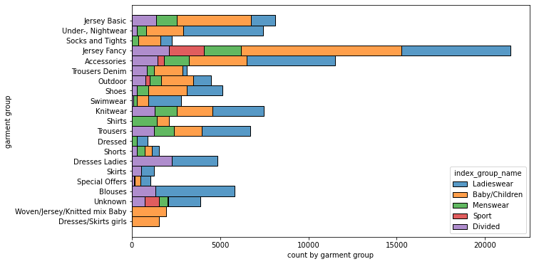

```python
f, ax = plt.subplots(figsize=(10, 6))
ax = sns.histplot(data=articles, y='garment_group_name',  hue='index_group_name', multiple="stack")
ax.set_xlabel('count by garment group')
ax.set_ylabel('garment group')
plt.show()
```

### 3.2.3. As it seems clear here, women's clothing has the highest share and sportswear has the least share.

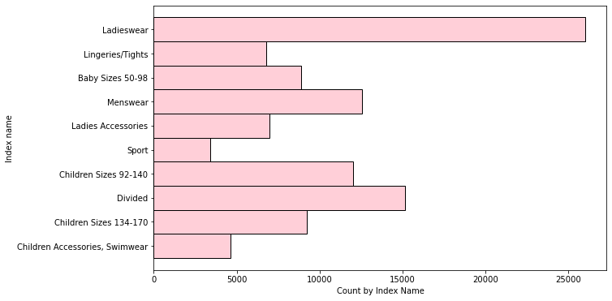

```python
a, sx = plt.subplots(figsize=(10, 6))
sx = sns.histplot(data=articles, y='index_name', color = "pink")
sx.set_xlabel('Count by Index Name')
sx.set_ylabel('Index name')
plt.show()
```

### 4. Customers Variable Descriptions

Customer Related Columns :

1. customer_id:an unique identifier of the customer

Product Related Columns :

1. FN:1 or NaN.
2. Active: Binary feature 1 or NaN. Is the user active or not?
3. club_member_status: Status in club.
4. fashion_news_frequency:How often can H&M send news to the customer? (For example e-mail)
5. age:Customer's age.
6. postal_code: Customer's postal code.

### 4.1 Customers : View customers data.

```python
customers.head()
```

|  | customer_id | FN | Active | club_member_status | fashion_news_frequency | age | postal_code |
| --- | --- | --- | --- | --- | --- | --- | --- |
| 0 | 00000dbacae5abe5e23885899a1fa44253a17956c6d1c3... | NaN | NaN | ACTIVE | NONE | 49.0 | 52043ee2162cf5aa7ee79974281641c6f11a68d276429a... |
| 1 | 0000423b00ade91418cceaf3b26c6af3dd342b51fd051e... | NaN | NaN | ACTIVE | NONE | 25.0 | 2973abc54daa8a5f8ccfe9362140c63247c5eee03f1d93... |
| 2 | 000058a12d5b43e67d225668fa1f8d618c13dc232df0ca... | NaN | NaN | ACTIVE | NONE | 24.0 | 64f17e6a330a85798e4998f62d0930d14db8db1c054af6... |
| 3 | 00005ca1c9ed5f5146b52ac8639a40ca9d57aeff4d1bd2... | NaN | NaN | ACTIVE | NONE | 54.0 | 5d36574f52495e81f019b680c843c443bd343d5ca5b1c2... |
| 4 | 00006413d8573cd20ed7128e53b7b13819fe5cfc2d801f... | 1.0 | 1.0 | ACTIVE | Regularly | 52.0 | 25fa5ddee9aac01b35208d01736e57942317d756b32ddd... |

### 4.1.2. Categorical Variable

```python
import seaborn as sns
from matplotlib import pyplot as plt
def bar_plot(variable):
    var=customers[variable]
    varValue=var.value_counts()
    plt.figure(figsize=(10,6))
    plt.bar(varValue.index , varValue)
    plt.xticks(varValue.index, varValue.index.values)
    plt.ylabel("Frequency")
    plt.title(variable)
    plt.show()
    print("{}: \n {}"  .format(variable, varValue))
```

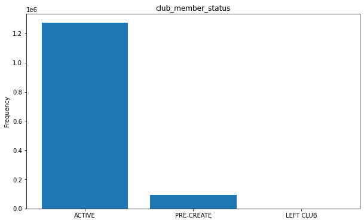

```
club_member_status:
 ACTIVE        1272491
PRE-CREATE      92960
LEFT CLUB         467
Name: club_member_status, dtype: int64
```

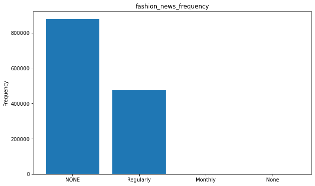

```
fashion_news_frequency:
 NONE         877711
Regularly    477416
Monthly         842
None              2
Name: fashion_news_frequency, dtype: int64
```

```python
category1 = ["club_member_status" , "fashion_news_frequency"]
for a in category1:
    bar_plot(a)
```

### 4.1.3.Most common age group in this dataframe with numerical variable

```python
import seaborn as sns
from matplotlib import pyplot as plt
def plot_hist(variable):
    plt.figure(figsize = (10,6))
    plt.hist(customers[variable])
    plt.xlabel(variable)
    plt.ylabel("Frequency")
    plt.title("{} distribution with hist." .format(variable))
    plt.show()
```

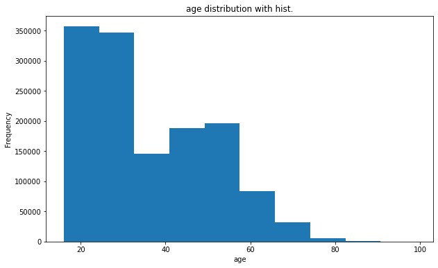

```python
numericVar=["age", "customer_id"]
for n in numericVar:
    plot_hist(n)
```

### 4.1.5. Status in H&M club. Almost every client has an active club status.Some customers have just started enabling it.

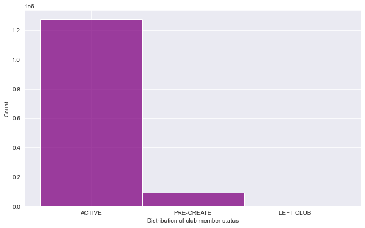

```python
sns.set_style("darkgrid")
f, ax = plt.subplots(figsize=(10,6))
ax = sns.histplot(data=customers, x='club_member_status', color='purple')
ax.set_xlabel('Distribution of club member status')
plt.show()
```

### 4.1.6. There are three types for no data here.

```python
customers['fashion_news_frequency'].unique()
```

```
array(['NONE', 'Regularly', nan, 'Monthly', 'None'], dtype=object)
```

### 4.1.7 Let's combine these values.

```python
customers.loc[~customers['fashion_news_frequency'].isin(['Regularly', 'Monthly']), 'fashion_news_frequency'] = 'None'
customers['fashion_news_frequency'].unique()
```

```
array(['None', 'Regularly', 'Monthly'], dtype=object)
```

### 4.1.8. customers in general. He/she doesn't want to receive e-mails or anything.

```python
var_data = customers[['customer_id', 'fashion_news_frequency']].groupby('fashion_news_frequency').count()
```

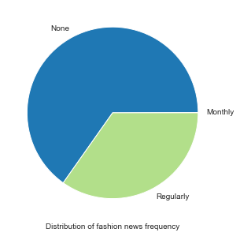

```python
sns.set_style("darkgrid")
f, ax = plt.subplots(figsize=(10,5))
colors = sns.color_palette('Paired')
ax.pie(pie_data.customer_id, labels=var_data.index, colors = colors)
ax.set_facecolor('lightgrey')
ax.set_xlabel('Distribution of fashion news frequency')
plt.show()
```

### 5. Transactions Variable Descriptions

1. t_dat: Date of a transaciton.
2. customer_id: Identifier of the customer which can be mapped to the customer_id column in the customers table.
3. article_id : Identifier of the product which can be mapped to the article_id column in the articles table
4. price : Price paid.
5. sales_channel_id: sales Channel 1 or 2.

```python
transactions.head()
```

|  | t_dat | customer_id | article_id | price | sales_channel_id |
| --- | --- | --- | --- | --- | --- |
| 0 | 2018-09-20 | 000058a12d5b43e67d225668fa1f8d618c13dc232df0ca... | 663713001 | 0.050831 | 2 |
| 1 | 2018-09-20 | 000058a12d5b43e67d225668fa1f8d618c13dc232df0ca... | 541518023 | 0.030492 | 2 |
| 2 | 2018-09-20 | 00007d2de826758b65a93dd24ce629ed66842531df6699... | 505221004 | 0.015237 | 2 |
| 3 | 2018-09-20 | 00007d2de826758b65a93dd24ce629ed66842531df6699... | 685687003 | 0.016932 | 2 |
| 4 | 2018-09-20 | 00007d2de826758b65a93dd24ce629ed66842531df6699... | 685687004 | 0.016932 | 2 |

### 5.1. Outliers for price

```python
pd.set_option('display.float_format', '{:.4f}'.format)
transactions.describe()['price']
```

```
count   31788324.0000
mean           0.0278
std            0.0192
min            0.0000
25%            0.0158
50%            0.0254
75%            0.0339
max            0.5915
Name: price, dtype: float64
```

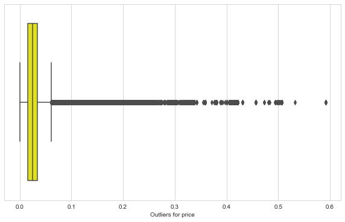

```python
sns.set_style("whitegrid")
f, ax = plt.subplots(figsize=(10,6))
ax = sns.boxplot(data=transactions, x='price', color='yellow')
ax.set_xlabel('Outliers for price')
plt.show()
```

### 5.1.2. The first five customers by the number of transactions with the customer id..

```python
transactions = transactions.groupby('customer_id').count()
```

```python
transactions.sort_values(by='price', ascending=False)['price'][:5]
```

```
customer_id
be1981ab818cf4ef6765b2ecaea7a2cbf14ccd6e8a7ee985513d9e8e53c6d91b    1895
b4db5e5259234574edfff958e170fe3a5e13b6f146752ca066abca3c156acc71    1441
49beaacac0c7801c2ce2d189efe525fe80b5d37e46ed05b50a4cd88e34d0748f    1364
a65f77281a528bf5c1e9f270141d601d116e1df33bf9df512f495ee06647a9cc    1361
cd04ec2726dd58a8c753e0d6423e57716fd9ebcf2f14ed6012e7e5bea016b4d6    1237
Name: price, dtype: int64
```

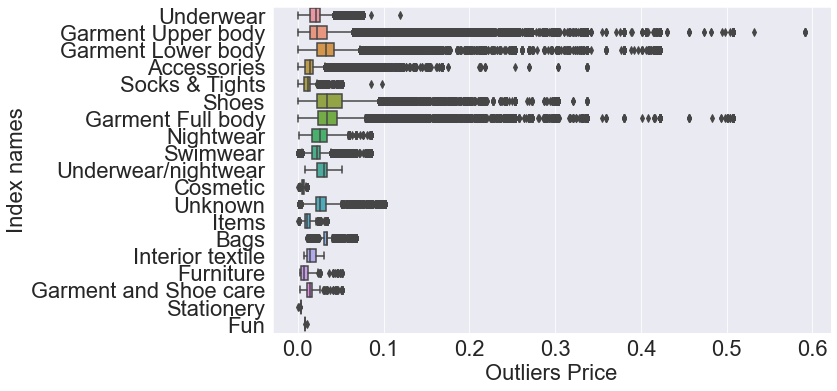

```python
sns.set_style("darkgrid")
f, ax = plt.subplots(figsize=(10,6))
ax = sns.boxplot(data=articles_for_merge, x='price', y='product_group_name')
ax.set_xlabel('Outliers Price', fontsize=22)
ax.set_ylabel('Index names', fontsize=22)
ax.xaxis.set_tick_params(labelsize=22)
ax.yaxis.set_tick_params(labelsize=22)

plt.show()
```